# Data Mining Final Project

Wanying Wang & Yue Ma

12/17/2018

# Prediction of Housing Price in Ames

## 1.Overview

- This project grew out of curiosity about how much a house in Ames, Iowa will cost when given some informaiton about the particular house. The aim of this project is to practice the techniques of data mining especially the some models frequently used in prediction such as Lasso and random forest, though we will not limit our analysis only within these two models. We try to develop our techniques with real world dataset to provide some insights for better prediction in housing price.
- The dataset we use was collected from residential homes in Ames, Iowa and contains 1460 observations and 79 explanatory variables describing almost every aspect of those homes. Our dependent variable is **SalePrice**. Below is the independent variables and dependent variable:

```r
hp <- read.csv("housing_price.csv")
dim(hp)
```

```
## [1] 1460   81
```

```r
colnames(hp)
```

```
##  [1] "Id"            "MSSubClass"    "MSZoning"      "LotFrontage"
##  [5] "LotArea"       "Street"        "Alley"         "LotShape"
##  [9] "LandContour"   "Utilities"     "LotConfig"     "LandSlope"
## [13] "Neighborhood"  "Condition1"    "Condition2"    "BldgType"
## [17] "HouseStyle"    "OverallQual"   "OverallCond"   "YearBuilt"
## [21] "YearRemodAdd"  "RoofStyle"     "RoofMatl"      "Exterior1st"
## [25] "Exterior2nd"   "MasVnrType"    "MasVnrArea"    "ExterQual"
## [29] "ExterCond"     "Foundation"    "BsmtQual"      "BsmtCond"
## [33] "BsmtExposure"  "BsmtFinType1"  "BsmtFinSF1"    "BsmtFinType2"
## [37] "BsmtFinSF2"    "BsmtUnfSF"     "TotalBsmtSF"   "Heating"
## [41] "HeatingQC"     "CentralAir"    "Electrical"    "X1stFlrSF"
## [45] "X2ndFlrSF"     "LowQualFinSF"  "GrLivArea"     "BsmtFullBath"
## [49] "BsmtHalfBath"  "FullBath"      "HalfBath"      "BedroomAbvGr"
## [53] "KitchenAbvGr"  "KitchenQual"   "TotRmsAbvGrd"  "Functional"
## [57] "Fireplaces"    "FireplaceQu"   "GarageType"    "GarageYrBlt"
## [61] "GarageFinish"  "GarageCars"    "GarageArea"    "GarageQual"
## [65] "GarageCond"    "PavedDrive"    "WoodDeckSF"    "OpenPorchSF"
## [69] "EnclosedPorch" "X3SsnPorch"    "ScreenPorch"   "PoolArea"
## [73] "PoolQC"        "Fence"         "MiscFeature"   "MiscVal"
## [77] "MoSold"        "YrSold"        "SaleType"      "SaleCondition"
## [81] "SalePrice"
```

## 2. Analyze the Data

### 2.1 Recoding the data

- To begin with, we found there are some factor variables are in wrong order(alphabetic order), so we convert them into right order, then convert them into numeric variable to facilitate the following operations.

```r
## ExterQual
hp$ExterQual <- factor(hp$ExterQual, levels = c("Po", "Fa", "TA", "Gd", "Ex"))
hp$ExterQual <- as.numeric(hp$ExterQual)
## ExterCond
hp$ExterCond <- factor(hp$ExterCond, levels = c("Po", "Fa", "TA", "Gd", "Ex"))
hp$ExterCond <- as.numeric(hp$ExterCond)
## GarageQual
hp$GarageQual <- factor(hp$GarageQual, levels = c("NA", "Po", "Fa", "TA", "Gd", "Ex"))
hp$GarageQual <- as.numeric(hp$GarageQual)
## GarageCond
hp$GarageCond <- factor(hp$GarageCond, levels = c("NA", "Po", "Fa", "TA", "Gd", "Ex"))
hp$GarageCond <- as.numeric(hp$GarageCond)
## FireplaceQu
hp$FireplaceQu <- factor(hp$FireplaceQu, levels = c("NA", "Po", "Fa", "TA", "Gd", "Ex"))
hp$FireplaceQu <- as.numeric(hp$FireplaceQu)
## KitchenQual
hp$KitchenQual <- factor(hp$KitchenQual, levels = c("Po", "Fa", "TA", "Gd", "Ex"))
hp$KitchenQual <- as.numeric(hp$KitchenQual)
## HeatingQC
hp$HeatingQC <- factor(hp$HeatingQC, levels = c("Po", "Fa", "TA", "Gd", "Ex"))
hp$HeatingQC <- as.numeric(hp$HeatingQC)
## BsmtQual
hp$BsmtQual <- factor(hp$BsmtQual, levels = c("NA", "Po", "Fa", "TA", "Gd", "Ex"))
hp$BsmtQual <- as.numeric(hp$BsmtQual)
## BsmtCond
hp$BsmtCond <- factor(hp$BsmtCond, levels = c("NA", "Po", "Fa", "TA", "Gd", "Ex"))
hp$BsmtCond <- as.numeric(hp$BsmtCond)
## PoolQC
hp$PoolQC <- factor(hp$PoolQC, levels = c("NA", "Fa", "TA", "Gd", "Ex"))
hp$PoolQC <- as.numeric(hp$PoolQC)
```

```r
## BsmtExposure
hp$BsmtExposure <- factor(hp$BsmtExposure, levels = c("NA", "No", "Mn", "Av", "Gd"))
hp$BsmtExposure <- as.numeric(hp$BsmtExposure)
```

```r
## BsmtFinType1
hp$BsmtFinType1 <- factor(hp$BsmtFinType1, levels = c("NA", "Unf", "LwQ", "Rec", "BLQ", "ALQ", "GLQ"))
hp$BsmtFinType1 <- as.numeric(hp$BsmtFinType1)
## BsmtFinType2
hp$BsmtFinType2 <- factor(hp$BsmtFinType2, levels = c("NA", "Unf", "LwQ", "Rec", "BLQ", "ALQ", "GLQ"))
hp$BsmtFinType2 <- as.numeric(hp$BsmtFinType2)
```

```r
## Functional
hp$Functional <- factor(hp$Functional, levels = c("Sal", "Sev", "Maj2", "Maj1", "Mod", "Min2", "Min1", "Typ"))
hp$Functional <- as.numeric(hp$Functional)
```

```r
## GarageFinish
hp$GarageFinish <- factor(hp$GarageFinish, levels = c("NA", "Unf", "RFn", "Fin"))
hp$GarageFinish <- as.numeric(hp$GarageFinish)
```

```r
## Fence
hp$Fence <- factor(hp$Fence, levels = c("MnWw", "GdWo", "MnPrv", "GdPrv"))
hp$Fence <- as.numeric(hp$Fence)
```

- Now, we have transformed all the factor variables with right order into numeric columns.

### 2.2 Missing Data

- In order to make this dataset into a complete one, which will be helpful for our future analysis and prediction but also guarantee we do not throw away valuable information, we firstly explore the completeness of this dataset and deal with NAs.
- Since this dataset contains numeric and categorical variables, we will examine them seperately. First is the numeric variables.

```r
library(dplyr)
## Extract numeric columns
numericVar <- select_if(hp, is.numeric)
## Calculate the percentage of NAs in numeric variables
numericNA <- as.data.frame(round(sort(colSums(is.na(numericVar))/nrow(numericVar), decreasing = T)*100, digits = 2))
colnames(numericNA) <- "percentage of NA"
numericNA
```

```
##               percentage of NA
## PoolQC                   99.52
## Fence                    80.75
## FireplaceQu              47.26
## LotFrontage              17.74
## GarageYrBlt               5.55
## GarageFinish              5.55
## GarageQual                5.55
## GarageCond                5.55
## BsmtExposure              2.60
## BsmtFinType2              2.60
## BsmtQual                  2.53
## BsmtCond                  2.53
## BsmtFinType1              2.53
## MasVnrArea                0.55
## Id                        0.00
## MSSubClass                0.00
## LotArea                   0.00
## OverallQual               0.00
## OverallCond               0.00
## YearBuilt                 0.00
## YearRemodAdd              0.00
## ExterQual                 0.00
## ExterCond                 0.00
## BsmtFinSF1                0.00
## BsmtFinSF2                0.00
## BsmtUnfSF                 0.00
## TotalBsmtSF               0.00
## HeatingQC                 0.00
## X1stFlrSF                 0.00
## X2ndFlrSF                 0.00
## LowQualFinSF              0.00
## GrLivArea                 0.00
## BsmtFullBath              0.00
## BsmtHalfBath              0.00
## FullBath                  0.00
## HalfBath                  0.00
## BedroomAbvGr              0.00
## KitchenAbvGr              0.00
## KitchenQual               0.00
## TotRmsAbvGrd              0.00
## Functional                0.00
## Fireplaces                0.00
## GarageCars                0.00
## GarageArea                0.00
## WoodDeckSF                0.00
## OpenPorchSF               0.00
## EnclosedPorch             0.00
## X3SsnPorch                0.00
## ScreenPorch               0.00
## PoolArea                  0.00
## MiscVal                   0.00
## MoSold                    0.00
## YrSold                    0.00
## SalePrice                 0.00
```

- Seeing from the table above, we can find that **PoolQC**, **Fence** and **FireplaceQu** these three variables have relatively higher percentage of NAs.
- Next, we will focus on categorical variables (those categorical variable are coded as factor originnaly, we will deal with this later. Now, we just treat them as factor.):

```r
## Extract factor variables
factorVar <- select_if(hp, is.factor)
## Calculate the percentage of NAs in categorical variables
factorNA <- as.data.frame(round(sort(colSums(is.na(factorVar)) / nrow(factorVar),decreasing = T) * 100, digits = 2))
colnames(factorNA) <- "percentage of NA"
factorNA
```

```
##               percentage of NA
## MiscFeature              96.30
## Alley                    93.77
## GarageType                5.55
## MasVnrType                0.55
## Electrical                0.07
## MSZoning                  0.00
## Street                    0.00
## LotShape                  0.00
## LandContour               0.00
## Utilities                 0.00
## LotConfig                 0.00
## LandSlope                 0.00
## Neighborhood              0.00
## Condition1                0.00
## Condition2                0.00
## BldgType                  0.00
## HouseStyle                0.00
## RoofStyle                 0.00
## RoofMatl                  0.00
## Exterior1st               0.00
## Exterior2nd               0.00
## Foundation                0.00
## Heating                   0.00
## CentralAir                0.00
## PavedDrive                0.00
## SaleType                  0.00
## SaleCondition             0.00
```

- Seeing from the table above, we can find that **MiscFeature** and **Alley** these two variables have very high propotion of NAs.
- Having refered to the codebook, we find that **PoolQC**, **Fence**, **MiscFeature** and **Alley** represent “Pool area in square feet”, , “Fence quality”, “Miscellaneous feature not covered in other categories” and “Type of alley access to property”. For the consideration that the first four factor variables with highest propotion of NAs are not the main elements that people take into consideration when they choose a house, so we just delet them from the dataset. For the rest of other variables, we just remove the NA directly.

```r
## Delete the four numeric variables with high propotion of NAs
newhp1 <- subset(hp, select = -c (PoolQC, MiscFeature, Alley, Fence))

## Remove NA directly
newhp1 <- na.omit(newhp1)
dim(newhp1)
```

```
## [1] 583  77
```

- Having remove NAs, we found we have lost more than half of the observations, so we decided to replace NAs with mean values of numeric variables and delete the NAs in categorical columns directly.

```r
## Delete the four numeric variables with high propotion of NAs
newhp2 <- subset(hp, select = -c (PoolQC, MiscFeature, Alley, Fence))

 ## Replace the NAs with the mean of numeric column
for (i in 2:ncol(newhp2) - 1L){
  newhp2[is.na(newhp2[,i]), i] <- round(mean(newhp2[,i], na.rm = TRUE), digits = 2)
}
```

```r
## Remove the NA in categorical columns
newhp2 <- na.omit(newhp2)
dim(newhp2)
```

```
## [1] 1370   77
```

- So, we finally have 1370 observations to analyze.

### 2.3 Descriptive Summary of Dependet Variable: **SalePrice**

```r
summary(newhp2$SalePrice)
```

```
##    Min. 1st Qu.  Median    Mean 3rd Qu.    Max.
##   35311  133925  167000  185195  217875  755000
```

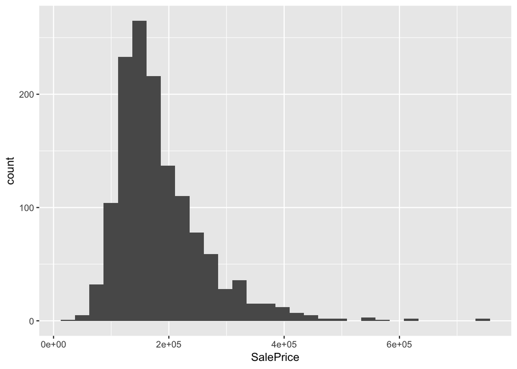

```r
library(ggplot2)
normality <- ggplot(newhp2)
normality <- normality + geom_histogram(mapping = aes(SalePrice),bins = 30)
normality
```

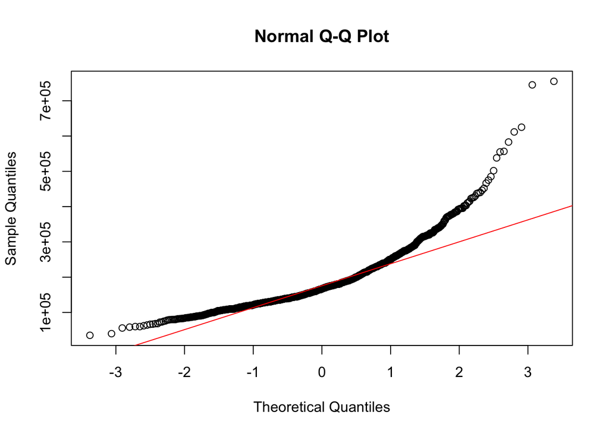

```r
qqnorm(newhp2$SalePrice)
qqline(newhp2$SalePrice,col = 2)
```

- Judging from the two figures above, we can find that our dependet variable is right skewed and does not follow the diagonal line. So, when we do our modeling thing, we need to do log transforamtion to this variable in order to normalize it, which is helpful for the rest of the prediction.

```r
newhp2$SalePrice <- log(newhp2$SalePrice)
```

### 2.4 Manipulate the Independent Variables

- In this part, we will first explore the correlation between the response variable and the explanatory variables and the multicollinearity.

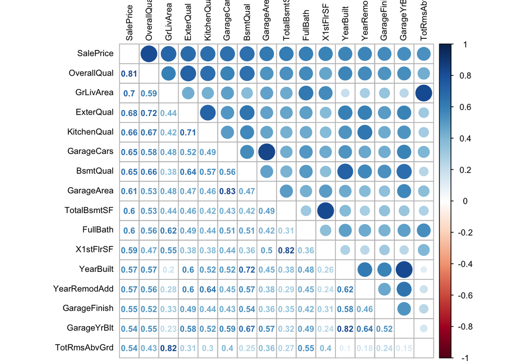

```r
## Convert the factor variables into numeric ones
for (i in 2:ncol(newhp2) - 1L) {
  if (is.factor(newhp2[,i])) {newhp2[,i] <- as.numeric(newhp2[,i])}
}
## correlations of all numeric variables
cor_Var <- cor(newhp2, use = "pairwise.complete.obs")
## sort on decreasing correlations with SalePrice
cor_sorted <- as.matrix(sort(cor_Var[,'SalePrice'], decreasing = TRUE))
## select only high corelations(correlation > 0.5)
CorHigh <- names(which(apply(cor_sorted, 1, function(x) abs(x) > 0.5)))
cor_Var <- cor_Var[CorHigh, CorHigh]
## plot it out
library(corrplot)
corrplot.mixed(cor_Var, tl.col = "black", tl.pos = "lt", tl.cex = 0.7, cl.cex = .7, number.cex = .7)
```

- Next, we will roughly explore the relationship betweent the **SalePrice** and some independent variables of high correlation.

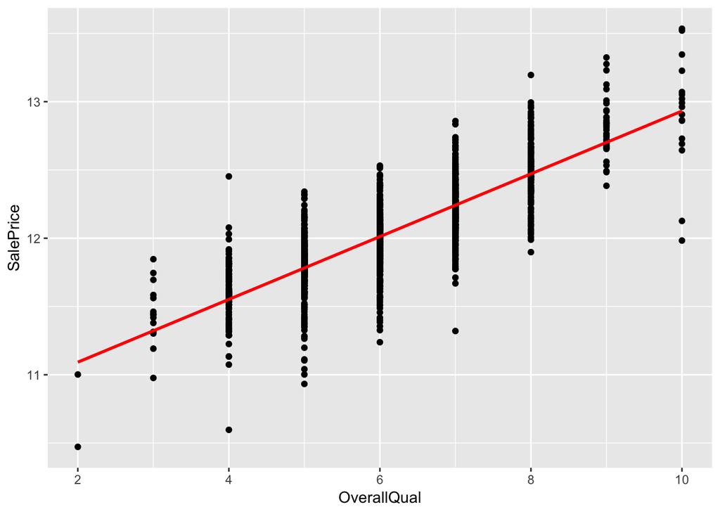

```r
## OverallQual
overallqual <- ggplot(newhp2, aes(x = OverallQual, y= SalePrice)) + geom_point() + geom_smooth(method = "lm", se = FALSE, color = "red", aes(group = 1))
overallqual
```

- There is a positive linear relationship between them judging from the plot above.

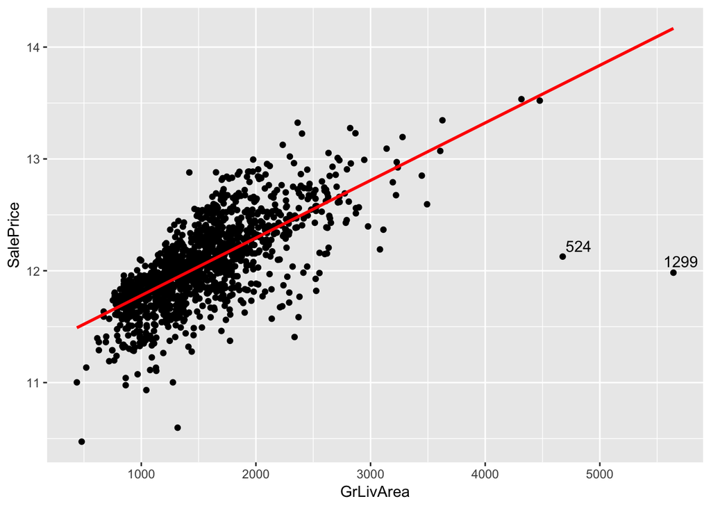

```r
library(ggrepel)
grlivarea <- ggplot(newhp2, aes(x = GrLivArea, y = SalePrice)) +
  geom_point() + geom_smooth(method = "lm", se = FALSE, color = "red", aes(group = 1)) +
  geom_text_repel(aes(label = ifelse(newhp2$GrLivArea > 4500, rownames(newhp2), '')))
grlivarea
```

- There is a positive linear relationship between them. However, we found there are two observations that have very big area but with oddly low price. So, they may be the outlier.

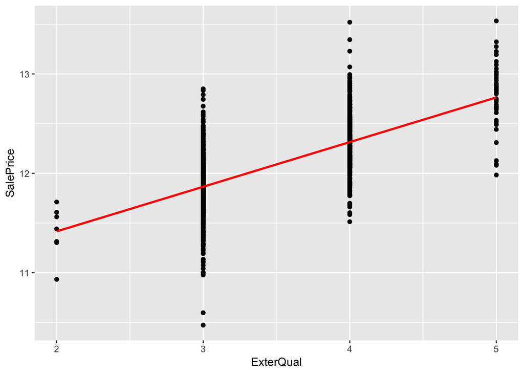

```r
## ExterQual
exterqual <- ggplot(newhp2, aes(x = ExterQual, y = SalePrice)) + geom_point() + geom_smooth(method = "lm", se = FALSE, color = "red", aes(group = 1))
exterqual
```

- There is a positive linear relationship, too.

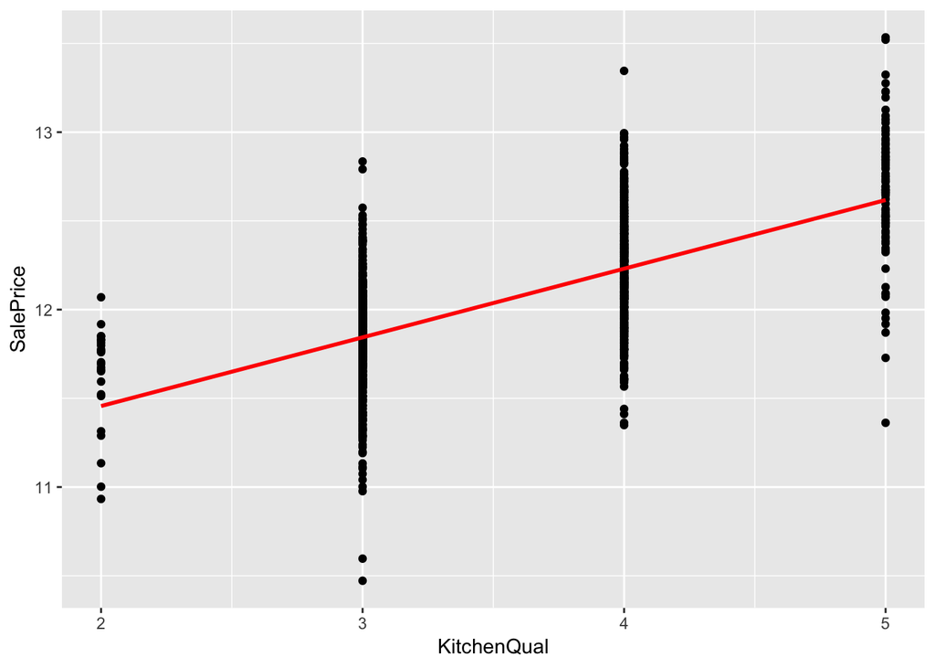

```r
## KitchenQual
kitchenqual <- ggplot(newhp2, aes(x = KitchenQual, y = SalePrice)) + geom_point() + geom_smooth(method = "lm", se = FALSE, color = "red", aes(group = 1))
kitchenqual
```

- There is a positive linear relationship, too.

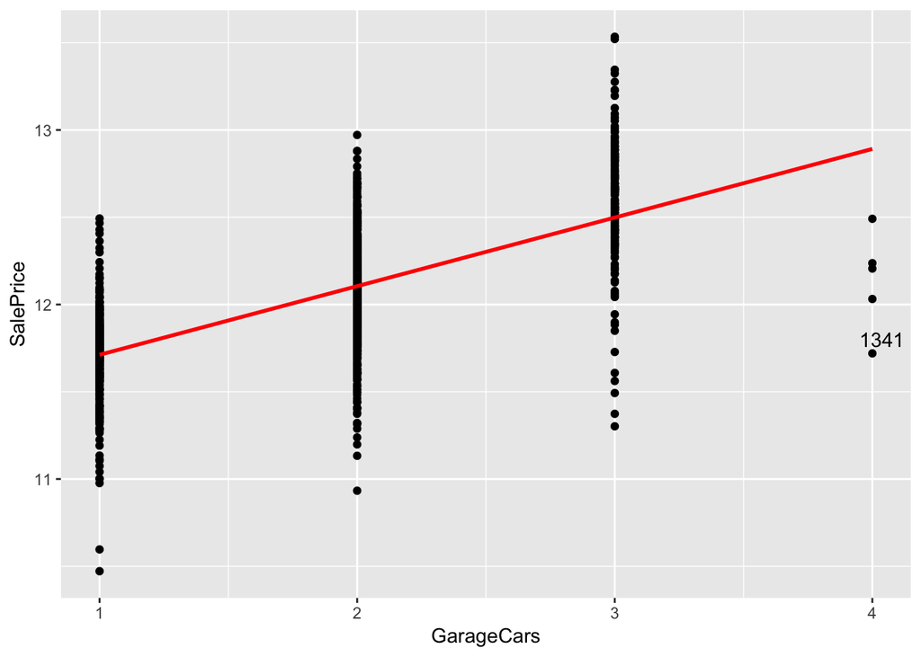

```r
## GarageCars
garagecars <- ggplot(newhp2, aes(x = GarageCars, y = SalePrice)) + geom_point() + geom_smooth(method = "lm", se = FALSE, color = "red", aes(group = 1)) +
  geom_text_repel(aes(label = ifelse(newhp2$GarageCars == 4 & newhp2$SalePrice < 12, rownames(newhp2), '')))
garagecars
```

- Seeing from the five pictures above, we can exclude some observations who are outliers in order for more accurate prediction when do further analysis in the following models.

## 3. Models

### 3.1 Baseline Model

```r
# split the dataset into training and testing
library(caret)
set.seed(20181219)
in_train <- createDataPartition(y = newhp2$SalePrice,
                                p = 3 / 4, list = FALSE)
training <- newhp2[ in_train, ]
testing <- newhp2[-in_train, ]
```

```r
# run with linear model
ols <- lm(SalePrice ~ . , data = training)
summary(ols)
```

```
##
## Call:
## lm(formula = SalePrice ~ ., data = training)
##
## Residuals:
##      Min       1Q   Median       3Q      Max
## -1.44557 -0.06401  0.00241  0.07006  0.51502
##
## Coefficients: (2 not defined because of singularities)
##                 Estimate Std. Error t value Pr(>|t|)
## (Intercept)    1.543e+01  6.699e+00   2.303 0.021518 *
## Id            -5.574e-06  1.042e-05  -0.535 0.592931
## MSSubClass    -3.104e-04  2.414e-04  -1.286 0.198867
## MSZoning      -1.053e-02  7.756e-03  -1.358 0.174708
## LotFrontage   -7.346e-04  2.552e-04  -2.879 0.004083 **
## LotArea        1.133e-06  5.193e-07   2.182 0.029333 *
## Street         2.376e-01  8.565e-02   2.774 0.005641 **
## LotShape      -1.029e-02  3.379e-03  -3.044 0.002399 **
## LandContour    1.474e-02  7.196e-03   2.049 0.040779 *
## Utilities     -2.178e-01  1.442e-01  -1.510 0.131360
## LotConfig      8.347e-04  2.765e-03   0.302 0.762832
## LandSlope      6.617e-02  1.974e-02   3.353 0.000832 ***
## Neighborhood   1.667e-03  8.072e-04   2.065 0.039165 *
## Condition1     2.198e-03  5.188e-03   0.424 0.671903
## Condition2    -3.752e-02  1.499e-02  -2.503 0.012498 *
## BldgType      -1.241e-02  7.779e-03  -1.595 0.110944
## HouseStyle    -5.970e-03  3.386e-03  -1.763 0.078226 .
## OverallQual    6.578e-02  6.381e-03  10.309  < 2e-16 ***
## OverallCond    3.972e-02  5.806e-03   6.842 1.39e-11 ***
## YearBuilt      1.707e-03  4.404e-04   3.875 0.000114 ***
## YearRemodAdd   1.523e-04  3.686e-04   0.413 0.679577
## RoofStyle      4.444e-03  5.807e-03   0.765 0.444378
## RoofMatl       1.548e-02  7.196e-03   2.151 0.031749 *
## Exterior1st   -6.011e-03  2.703e-03  -2.224 0.026370 *
## Exterior2nd    7.289e-03  2.428e-03   3.002 0.002751 **
## MasVnrType     1.408e-03  7.823e-03   0.180 0.857168
## MasVnrArea     5.024e-06  2.947e-05   0.170 0.864679
## ExterQual      1.705e-02  1.359e-02   1.255 0.209905
## ExterCond     -2.152e-02  1.488e-02  -1.446 0.148510
## Foundation     7.591e-03  9.014e-03   0.842 0.399908
```

[output cut: 38 more lines]

```
## EnclosedPorch  2.202e-04  8.265e-05   2.665 0.007833 **
## X3SsnPorch     1.792e-04  1.354e-04   1.323 0.186083
## ScreenPorch    3.078e-04  7.783e-05   3.955 8.21e-05 ***
## PoolArea      -1.863e-04  1.018e-04  -1.830 0.067504 .
## MiscVal        2.490e-06  7.677e-06   0.324 0.745716
## MoSold         1.073e-03  1.644e-03   0.653 0.514206
## YrSold        -3.912e-03  3.315e-03  -1.180 0.238219
## SaleType       1.993e-05  2.848e-03   0.007 0.994418
## SaleCondition  2.091e-02  4.464e-03   4.684 3.22e-06 ***
## ---
## Signif. codes:  0 '***' 0.001 '**' 0.01 '*' 0.05 '.' 0.1 ' ' 1
##
## Residual standard error: 0.135 on 955 degrees of freedom
## Multiple R-squared:  0.884,  Adjusted R-squared:  0.875
## F-statistic: 98.32 on 74 and 955 DF,  p-value: < 2.2e-16
```

```r
# predict in the testing data and calculate RMSE
y_hat <- predict(ols, newdata = testing)
defaultSummary(data.frame(obs = testing$SalePrice, pred = y_hat))
```

```
##       RMSE   Rsquared        MAE
## 0.13379084 0.87306995 0.09600235
```

### 3.2 Penalized Model - Elstic-net model

```r
y_hat_glmnet <- predict(enet, newdata = testing)
defaultSummary(data.frame(obs = testing$SalePrice, pred = y_hat_glmnet))
```

[output not shown]

```
##       RMSE   Rsquared        MAE
## 0.13082401 0.88405944 0.09229469
```

```r
# see the feature importance in elastic-net model
varImp(enet)
```

```
## glmnet variable importance
##
##   only 20 most important variables shown (out of 76)
##
##               Overall
## OverallQual    100.00
## GrLivArea       63.12
## GarageCars      43.14
## Fireplaces      38.56
## OverallCond     35.76
## KitchenQual     35.24
## TotRmsAbvGrd    33.04
## X1stFlrSF       32.69
## BsmtQual        27.54
## FullBath        24.64
## BsmtFinType1    24.17
## SaleCondition   23.25
## ExterQual       23.03
## YearBuilt       22.06
## CentralAir      20.51
## TotalBsmtSF     19.62
## GarageArea      18.06
## HeatingQC       18.04
## Functional      17.48
## LotShape        15.86
```

### 3.3 Tree-based model

#### 3.3.1 Bagging

- Tree-based models involve stratifying or segmenting the predictor space into a number of simple regions. Bagging, random forests, and boosting use trees as building blocks to construct more powerful prediction models. We strat from bagging model.

```r
# bagging
bag <- train(SalePrice ~ ., data = training, method = "treebag",
             na.action = na.omit, trControl = ctrl)
y_hat_treebag <- predict(bag, newdata = testing)
defaultSummary(data.frame(obs = testing$SalePrice, pred = y_hat_treebag))
```

```
##      RMSE  Rsquared       MAE
## 0.1775946 0.7796179 0.1273802
```

```r
# features importance in bagging
varImp(bag)
```

```
## treebag variable importance
##
##   only 20 most important variables shown (out of 76)
##
##              Overall
## GrLivArea     100.00
## OverallQual    89.42
## X1stFlrSF      70.19
## TotalBsmtSF    68.90
## BsmtFinSF1     56.15
## GarageArea     48.07
## GarageCars     47.60
## YearBuilt      42.56
## BsmtQual       35.59
## KitchenQual    29.97
## ExterQual      28.55
## LotArea        25.27
## GarageFinish   20.15
## YearRemodAdd   17.76
## Fireplaces     14.91
## LotFrontage    14.69
## X2ndFlrSF      12.60
## OverallCond    12.53
## CentralAir     12.07
## MSZoning       11.32
```

#### 3.3.2 Boosting

- Like bagging, boosting is a general approach that can be applied to many statistical learning methods for regression or classification.
- Boosting works in a similar way wih Bagging, except that the trees are grown *sequentially*: each tree is grown using information from previously grown trees. Boosting does not involve bootstrap sampling; instead each tree is fit on a modified version of the original data set.

```r
y_hat_gbm <- predict(boosted, newdata = testing)
defaultSummary(data.frame(obs = testing$SalePrice, pred = y_hat_gbm))
```

[output not shown]

```
##      RMSE  Rsquared       MAE
## 0.1272331 0.8851351 0.0835906
```

#### 3.3.3 Random Forest

- Random forests provide an improvement over bagged trees by way of a small tweak that decorrelates the trees. Random forests overcome this problem by forcing each split to consider only a subset of the predictors. We use Random Forest here.

```r
# Random Forest
rf_grid <- data.frame(.mtry = 2:(ncol(training) - 1L))
rf <- train(SalePrice ~ ., data = training, method = "rf",
            ntrees = 100, trControl = ctrl,
            na.action = na.omit,
            importance = TRUE)
y_hat_rf <- predict(rf, newdata = testing)
defaultSummary(data.frame(obs = testing$SalePrice, pred = y_hat_rf))
```

```
##       RMSE   Rsquared        MAE
## 0.13511652 0.87334568 0.08940828
```

```r
# see the feature importance in the Random Forest model
varImp(rf)
```

```
## rf variable importance
##
##   only 20 most important variables shown (out of 76)
##
##              Overall
## GrLivArea     100.00
## OverallQual    68.49
## TotalBsmtSF    59.75
## X1stFlrSF      52.57
## BsmtFinSF1     47.43
## LotArea        42.14
## GarageCars     39.56
## OverallCond    38.79
## GarageArea     36.22
## YearRemodAdd   35.99
## YearBuilt      32.17
## Fireplaces     32.12
## BsmtFinType1   30.69
## X2ndFlrSF      30.10
## Neighborhood   29.26
## ExterQual      28.68
## GarageType     27.56
## MSZoning       27.02
## LotFrontage    26.02
## KitchenQual    25.44
```

- In the Random Forest model, **GrLivArea**, **OverallQual**, **TotalBsmtSF**, **X1stFlrSF** are the most important features..
- The **Root Mean Square Error** of boosting model is smaller than that of the Random Forest model.

#### 3.3.4 Bayesian additive regression (BART)

- BART is a nonparametric Bayesian regression approach which uses dimensionally adaptive random basis elements. Motivated by ensemble methods in general, and boosting algorithms in particular, BART is defined by a statistical model: a prior and a likelihood.
- This approach enables full posterior inference including point and interval estimates of the unknown regression function as well as the marginal effects of potential predictors. By keeping track of predictor inclusion frequencies, BART can also be used for model-free variable selection.

```r
library(BART)
X_train <- model.matrix(SalePrice ~ ., data = training)
X_test <- model.matrix(SalePrice ~ ., data = testing)
bart <- mc.wbart(X_train, y = training$SalePrice, X_test,
                 mc.cores = parallel::detectCores())
defaultSummary(data.frame(obs = testing$SalePrice,
                          pred = exp(bart$yhat.test.mean)))
```

```
##         RMSE     Rsquared          MAE
## 1.983981e+05 8.663545e-01 1.855332e+05
```

- The **Root Mean Square Error** of boosting model is also smaller than that of Bayesian additive regression.

## 4. Conclusion & Discussion

- We still have a lot to improve, for example, to adjust more times about the tuning parameters in the model for machine learning in order to produce a lower rooted mean square error.
- Also in the data cleaning process, we replace NAs with mean values of numeric variables and delete the NAs in categorical columns directly. In the further project, we may adjust more manipulation of missing values.